# predicting Healthy Ride ridership with prophet

Conor Tompkins

6/21/2019

This post is about predicting demand for the Healthy Ride bike system in Pittsburgh. I wanted to try out Facebook’s `prophet` package and try to do some time series forecasting.

As usual, load the required packages and set up the environment:

```r
library(tidyverse)
library(lubridate)
library(prophet)
library(janitor)

options(scipen = 999)

theme_set(theme_bw())
```

This code loads the data and formats the date column so the `prophet` package can interface with it. I use `dir()` to find all the CSV files in the folder and then `set_names()` and `map_df(read_csv())` to read each of the CSV files into memory.

```r
source("scripts/load_data.R")
```

The data I will use contains the number of rides per day and also includes the month and year. `prophet` will identify the time series patterns (“seasonality”) in the data and identify the “true” pattern

```r
df <- df %>%
  count(date) %>%
  rename(ds = date,
         y = n) %>%
  mutate(floor = 0,
         cap = 1.5 * max(y))
```

```r
glimpse(df)
```

```
## Observations: 1,310
## Variables: 4
## $ ds    <date> 2015-05-31, 2015-06-01, 2015-06-02, 2015-06-03, 2015-06...
## $ y     <int> 3840, 1012, 1100, 1048, 1704, 2164, 3076, 3380, 1024, 20...
## $ floor <dbl> 0, 0, 0, 0, 0, 0, 0, 0, 0, 0, 0, 0, 0, 0, 0, 0, 0, 0, 0,...
## $ cap   <dbl> 12114, 12114, 12114, 12114, 12114, 12114, 12114, 12114, ...
```

This creates the set of holidays I use in the model.

```r
us_holidays <- prophet::generated_holidays %>%
  as_tibble() %>%
  filter(country == "US")
```

This code fits a model to the dataset.

```r
m <- prophet(df, growth = 'logistic', holidays = us_holidays)
```

`make_future_dataframe()` creates the dataframe that `prophet` uses to make its forecast. In this case, I have it create a dataframe with 365 days of additional rows to predict onto.

```r
future <- make_future_dataframe(m, periods = 365, freq = "day") %>%
  mutate(floor = 0,
         cap = 10^4)
```

This code performs the forecast on the future dataset.

```r
forecast <- predict(m, future) %>%
  as_tibble()
```

The output is a dataframe with the date, the predicted ridership, and the upper and lower bounds of the prediction.

```r
forecast
```

```
## # A tibble: 1,675 x 66
##    ds                  trend   cap floor additive_terms additive_terms_~
##    <dttm>              <dbl> <dbl> <dbl>          <dbl>            <dbl>
##  1 2015-05-31 00:00:00 1687. 10000     0          1292.            1292.
##  2 2015-06-01 00:00:00 1686. 10000     0           681.             681.
##  3 2015-06-02 00:00:00 1685. 10000     0           775.             775.
##  4 2015-06-03 00:00:00 1684. 10000     0           846.             846.
##  5 2015-06-04 00:00:00 1684. 10000     0           764.             764.
##  6 2015-06-05 00:00:00 1683. 10000     0           937.             937.
##  7 2015-06-06 00:00:00 1682. 10000     0          1414.            1414.
##  8 2015-06-07 00:00:00 1681. 10000     0          1281.            1281.
##  9 2015-06-08 00:00:00 1680. 10000     0           663.             663.
## 10 2015-06-09 00:00:00 1680. 10000     0           752.             752.
## # ... with 1,665 more rows, and 60 more variables:
## #   additive_terms_upper <dbl>, `Christmas Day` <dbl>, `Christmas
## #   Day_lower` <dbl>, `Christmas Day_upper` <dbl>, `Christmas Day
## #   (Observed)` <dbl>, `Christmas Day (Observed)_lower` <dbl>, `Christmas
## #   Day (Observed)_upper` <dbl>, `Columbus Day` <dbl>, `Columbus
## #   Day_lower` <dbl>, `Columbus Day_upper` <dbl>, holidays <dbl>,
## #   holidays_lower <dbl>, holidays_upper <dbl>, `Independence Day` <dbl>,
## #   `Independence Day_lower` <dbl>, `Independence Day_upper` <dbl>,
## #   `Independence Day (Observed)` <dbl>, `Independence Day
## #   (Observed)_lower` <dbl>, `Independence Day (Observed)_upper` <dbl>,
## #   `Labor Day` <dbl>, `Labor Day_lower` <dbl>, `Labor Day_upper` <dbl>,
## #   `Martin Luther King, Jr. Day` <dbl>, `Martin Luther King, Jr.
## #   Day_lower` <dbl>, `Martin Luther King, Jr. Day_upper` <dbl>, `Memorial
## #   Day` <dbl>, `Memorial Day_lower` <dbl>, `Memorial Day_upper` <dbl>,
## #   `New Year's Day` <dbl>, `New Year's Day_lower` <dbl>, `New Year's
## #   Day_upper` <dbl>, `New Year's Day (Observed)` <dbl>, `New Year's Day
## #   (Observed)_lower` <dbl>, `New Year's Day (Observed)_upper` <dbl>,
## #   Thanksgiving <dbl>, Thanksgiving_lower <dbl>,
## #   Thanksgiving_upper <dbl>, `Veterans Day` <dbl>, `Veterans
## #   Day_lower` <dbl>, `Veterans Day_upper` <dbl>, `Veterans Day
## #   (Observed)` <dbl>, `Veterans Day (Observed)_lower` <dbl>, `Veterans
## #   Day (Observed)_upper` <dbl>, `Washington's Birthday` <dbl>,
## #   `Washington's Birthday_lower` <dbl>, `Washington's
## #   Birthday_upper` <dbl>, weekly <dbl>, weekly_lower <dbl>,
## #   weekly_upper <dbl>, yearly <dbl>, yearly_lower <dbl>,
## #   yearly_upper <dbl>, multiplicative_terms <dbl>,
## #   multiplicative_terms_lower <dbl>, multiplicative_terms_upper <dbl>,
## #   yhat_lower <dbl>, yhat_upper <dbl>, trend_lower <dbl>,
## #   trend_upper <dbl>, yhat <dbl>
```

`plot` automatically plots the `forecast` data:

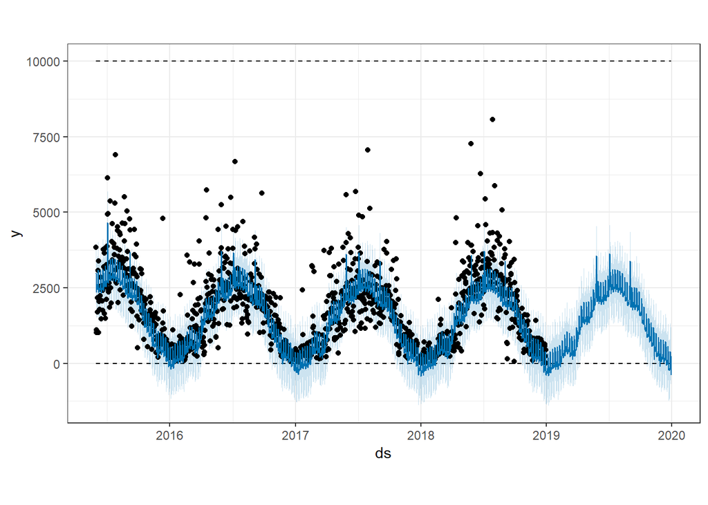

```r
plot(m, forecast)
```

`prophet` also decomposes the various time series seasonalities:

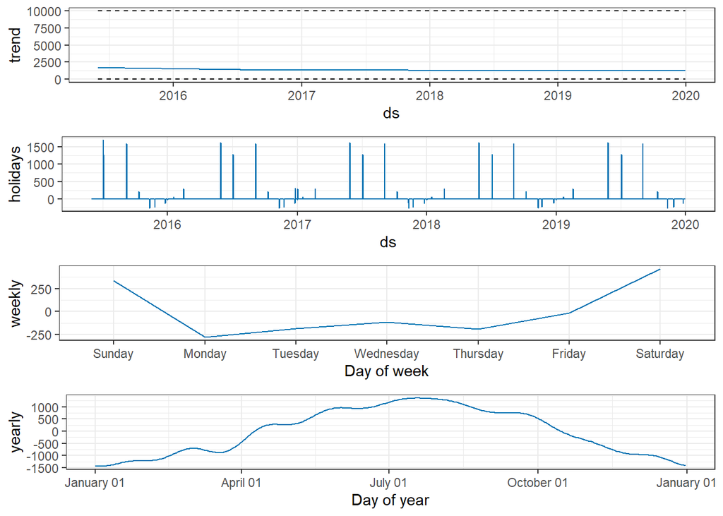

```r
prophet_plot_components(m, forecast)
```

```r
df_cv <- cross_validation(m, horizon = 30, units = 'days')
```

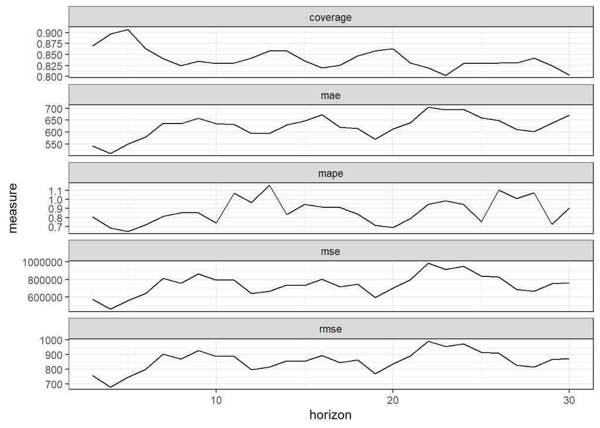

```r
performance_metrics(df_cv) %>%
  as_tibble() %>%
  gather(metric, measure, -horizon) %>%
  ggplot(aes(horizon, measure)) +
  geom_line() +
  facet_wrap(~metric, scales = "free_y",
             ncol = 1)
```

##Documentation and references

- https://facebook.github.io/prophet/